# Houston Texas

# Houson Texas Data

This will be the h3 hash generation work for Houston, Texas. The other city notebooks follow the same steps but with different sets of CBSA data.

Estimated time to run: 4.5+ hours

Load packages:

```r
library(ggplot2)
library(glue) # Interpreted String Literals
library(h3)
library(here) # A Simpler Way to Find Your Files
library(osmdata) # package for working with streets
library(sf) # Simple Features for R
library(tidycensus) # Load US Census Boundary and Attribute Data as 'tidyverse' and 'sf'-Ready Data Frames
library(tidyverse) # Easily Install and Load the 'Tidyverse'
library(tigris) # Load Census TIGER/Line Shapefiles
```

## Network data

Download OSM data for Houston [here](https://download.geofabrik.de/north-america/us/texas.html). It will be a proto-buffer file (pbf). Save under `data-raw/r5_graph`. (These files might not be visible on GitHub.)

## Census tracts

Obtain the census tracts for Houston. Note that [{tidycensus}](https://walker-data.com/tidycensus/) function `get_decenial()` allows the selection of state and county, but not metro area or city. Check the example [here](https://walker-data.com/census-r/spatial-analysis-with-us-census-data.html#identifying-geometries-within-a-metropolitan-area) to see how to select tracts in a city.

```r
options(tigris_use_cache = TRUE)

tx_tracts <- get_decennial(geography = "tract",
                           variables = "H1_001N",
                           state = "Texas",
                           year = 2020,
                           geometry = TRUE
)
```

```
Using the PL 94-171 Redistricting Data Summary File
```

```r
tx_city <- urban_areas(year = 2020) |>
  filter(str_detect(NAME10, "TX"))
```

A [core-based statistical area](https://en.wikipedia.org/wiki/Core-based_statistical_area) is a generous definition of the area of interest, since it contains an urban nucleus and also all neighboring communities that are tightly integrated with it. It is important to note that some of the neighboring communities share boundaries with the urban nucleus, but some are disconnected.

```r
houston_cbsa <- core_based_statistical_areas(year = 2020) |>
  filter(str_detect(NAME, "Houston"))
```

A much stricter definition of the area of interest would result from using the city boundaries, which can be obtained using `urban_areas()`:

```r
houston_city <- urban_areas(year = 2020) |>
  filter(str_detect(NAME10, "Houston"))
```

Plot the location of Houston CBSA within Texas and its tracts:

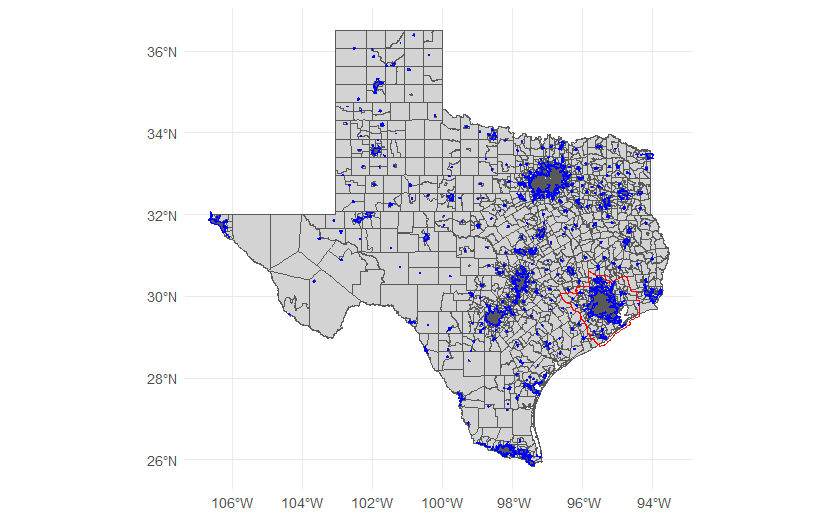

```r
ggplot() +
  geom_sf(data = tx_tracts,
          fill = "lightgrey") +
  geom_sf(data = houston_cbsa,
          color = "red",
          fill = NA) +
  geom_sf(data = tx_city,
          color = "blue",
          fill = NA) +
  theme_minimal()
```

Select all urban areas in Houston CBSA:

```r
houston_urban <- st_filter(tx_city, houston_cbsa)
```

Plot urban boundaries within the Houston CBSA:

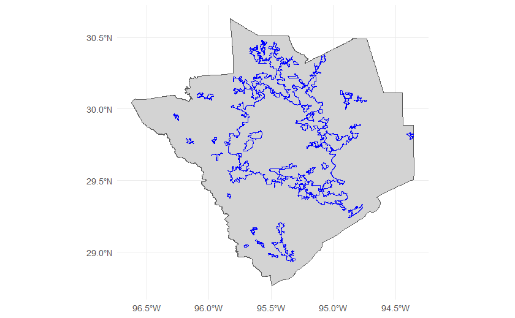

```r
ggplot() +
  geom_sf(data = houston_cbsa,
          fill = "lightgray") +
  geom_sf(data = houston_urban,
          color = "blue",
          fill = NA) +
  theme_minimal()
```

Obtain the Houston tracts:

```r
houston_tracts <- tx_tracts |>
  st_intersection(houston_urban)
```

Plot Houston’s urban tracts within the CBSA:

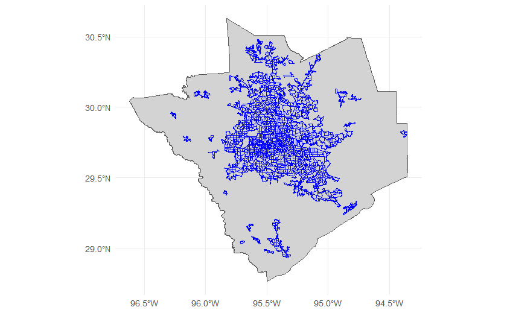

```r
ggplot() +
  geom_sf(data = houston_cbsa,
          fill = "lightgray") +
  geom_sf(data = houston_tracts,
          color = "blue",
          fill = NA) +
  theme_minimal()
```

## Geohashes

Use the coordinates of the centroid of Houston CBSA to obtain h3 polygons:

```r
coords <- st_centroid(houston_cbsa) |>
  st_coordinates()
print(coords)
```

```
             X        Y
[1,] -95.35389 29.74934
```

```r
print(rev(coords))
```

```
[1]  29.74934 -95.35389
```

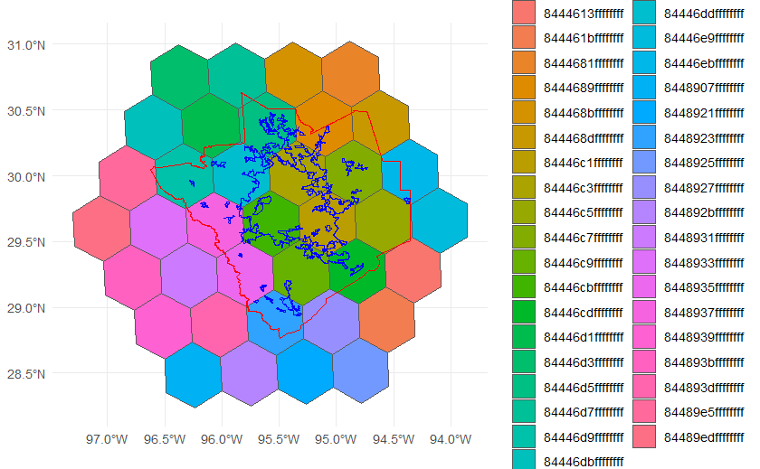

```r
houston_h3 <- geo_to_h3(c(rev(coords)),
                             res = 4) |>

  # nashville coordinates were taken from the generated coords in the chunk above (but the order is reversed) and are kept at 5 decimal points.

  k_ring(3)

# k_ring sets the number of h3 rings to generate around the initial h3 point, typically 2 or 3 are required depending on the CBSA.

ggplot() +
  geom_sf(data = (h3_to_geo_boundary_sf(houston_h3)),
          aes(fill = h3_index)) +
    geom_sf(data = houston_cbsa,
          color = "red",
          fill = NA) +
  geom_sf(data = houston_urban,
          color = "blue",
          fill = NA) +
  theme_minimal()
```

```r
print.listof(h3_to_geo_boundary_sf(houston_h3))
```

```
h3_index :
 [1] "84446cbffffffff" "84446c9ffffffff" "84446c1ffffffff" "84446c3ffffffff" "84446ddffffffff"
 [6] "8448937ffffffff" "8448935ffffffff" "8448923ffffffff" "8448927ffffffff" "84446cdffffffff"
[11] "84446c5ffffffff" "84446c7ffffffff" "8444689ffffffff" "84446d5ffffffff" "84446d1ffffffff"
[16] "84446d9ffffffff" "8448933ffffffff" "8448931ffffffff" "844893dffffffff" "844892bffffffff"
[21] "8448921ffffffff" "8448925ffffffff" "844461bffffffff" "8444613ffffffff" "84446e9ffffffff"
[26] "84446ebffffffff" "844468dffffffff" "8444681ffffffff" "844468bffffffff" "84446d7ffffffff"
[31] "84446d3ffffffff" "84446dbffffffff" "84489e5ffffffff" "84489edffffffff" "844893bffffffff"
[36] "8448939ffffffff" "8448907ffffffff"

geometry :
Geometry set for 37 features
Geometry type: POLYGON
Dimension:     XY
Bounding box:  xmin: -97.30405 ymin: 28.23331 xmax: -93.85366 ymax: 31.0243
Geodetic CRS:  WGS 84
First 5 geometries:
```

```
POLYGON ((-95.55714 29.38508, -95.31745 29.5155...
POLYGON ((-95.29626 29.01346, -95.05743 29.1438...
POLYGON ((-95.06749 29.39469, -94.82799 29.5241...
POLYGON ((-95.32811 29.76643, -95.08774 29.896,...
POLYGON ((-95.82009 29.75644, -95.57955 29.8871...
```

Keep only the h3 indices that overlap with urban Houston (but discard any that overlap 0-10%):

```r
houston_h3 = c("84446cbffffffff", "84446c9ffffffff", "84446c1ffffffff", "84446c3ffffffff", "84446ddffffffff", "8448937ffffffff", "8448935ffffffff", "8448923ffffffff", "84446cdffffffff", "84446c5ffffffff", "84446c7ffffffff", "8444689ffffffff", "84446d5ffffffff", "84446d9ffffffff", "84446ebffffffff")

# can be done through trial and error (take all h3 codes from the generated list and remove one-by-one, or remove based on h3 numbers as they go in a spiral starting from the centroid)
```

Plot kept indices:

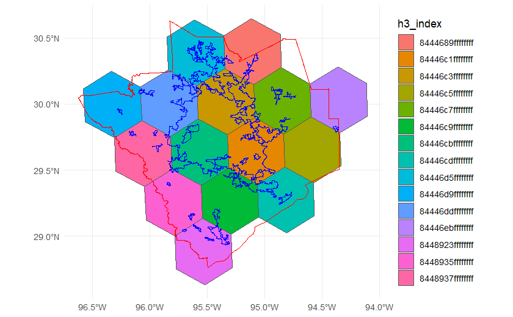

```r
ggplot() +
  geom_sf(data = h3_to_geo_boundary_sf(houston_h3),
          aes(fill = h3_index)) +
  geom_sf(data = houston_cbsa,
          color = "red",
          fill = NA) +
  geom_sf(data = houston_urban,
          color = "blue",
          fill = NA) +
  theme_minimal()
```

Obtain children hashes at a higher resolution (8):

```r
houston_h3 <- houston_h3 |>
  purrr::map(\(x) h3_to_children(x, res = 8)) |>
  unlist()
```

Choose only hexagons that touch urban Houston:

```r
houston_h3 <- h3_to_geo_boundary_sf(houston_h3) |>
  st_transform(crs = st_crs(houston_urban)) |>
  st_intersection(houston_urban)
houston_h3 <- houston_h3 |>
  pull(h3_index)
```

Plot resolution 8 hashes within Houston:

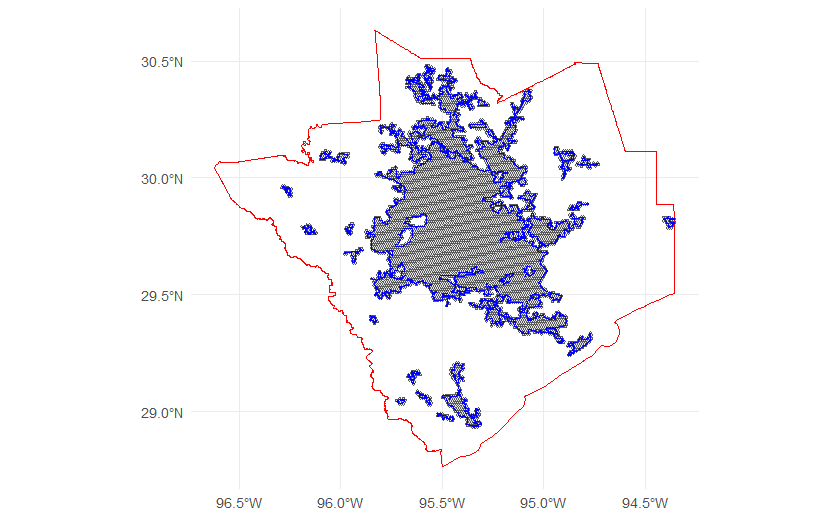

```r
ggplot() +
  geom_sf(data = h3_to_geo_boundary_sf(houston_h3)) +
  geom_sf(data = houston_cbsa,
          color = "red",
          fill = NA) +
  geom_sf(data = houston_urban,
          color = "blue",
          fill = NA) +
  theme_minimal()
```

Currently this is resolution 8:

```r
h3_get_resolution(houston_h3)
```

[output not shown]

Obtain children at resolution 13 (average area is ~49.47 $m^2$):

```r
houston_h3 <- houston_h3 |>
  purrr::map(\(x) h3_to_children(x, res = 13)) |>
  unlist()
```

Check the size of an h3 hexagon:

```r
sample_h3 <- h3_to_geo_boundary_sf(houston_h3[1])

sample_h3 |>
  mutate(area = st_area(geometry))
```

```
Simple feature collection with 1 feature and 2 fields
Geometry type: POLYGON
Dimension:     XY
Bounding box:  xmin: -95.95115 ymin: 29.75856 xmax: -95.95106 ymax: 29.75864
Geodetic CRS:  WGS 84
         h3_index                       geometry           area
1 8d489368920003f POLYGON ((-95.95108 29.7585... 49.47153 [m^2]
```

Information about housing characteristics. Explore the tables [here](https://data.census.gov/advanced?q=Housing) to get a sense of the variables that might be interesting to date the housing stock. For example, a search within the topic of “housing” shows that there is a set of variables with “physical characteristics”. The keywords for age of housing stock are “year” and “structure”. Next, use {tidycensus} to explore the variables available:

```r
v17 <- load_variables(2022,
                      "acs5",
                      cache = TRUE)


v17 |>
  filter(str_detect(concept, "Year") & str_detect(concept, "Structure"))
```

| name | label | concept | geography |
| --- | --- | --- | --- |
| B25034_001 | Estimate!!Total: | Year Structure Built | block group |
| B25034_002 | Estimate!!Total:!!Built 2020 or later | Year Structure Built | block group |
| B25034_003 | Estimate!!Total:!!Built 2010 to 2019 | Year Structure Built | block group |
| B25034_004 | Estimate!!Total:!!Built 2000 to 2009 | Year Structure Built | block group |
| B25034_005 | Estimate!!Total:!!Built 1990 to 1999 | Year Structure Built | block group |
| B25034_006 | Estimate!!Total:!!Built 1980 to 1989 | Year Structure Built | block group |
| B25034_007 | Estimate!!Total:!!Built 1970 to 1979 | Year Structure Built | block group |
| B25034_008 | Estimate!!Total:!!Built 1960 to 1969 | Year Structure Built | block group |
| B25034_009 | Estimate!!Total:!!Built 1950 to 1959 | Year Structure Built | block group |
| B25034_010 | Estimate!!Total:!!Built 1940 to 1949 | Year Structure Built | block group |

[output cut: 323 more lines]

Refine the search:

```r
v17 |>
  filter(str_detect(label, "Estimate!!Total:!!Built"))
```

| name | label | concept | geography |
| --- | --- | --- | --- |
| B25034_002 | Estimate!!Total:!!Built 2020 or later | Year Structure Built | block group |
| B25034_003 | Estimate!!Total:!!Built 2010 to 2019 | Year Structure Built | block group |
| B25034_004 | Estimate!!Total:!!Built 2000 to 2009 | Year Structure Built | block group |
| B25034_005 | Estimate!!Total:!!Built 1990 to 1999 | Year Structure Built | block group |
| B25034_006 | Estimate!!Total:!!Built 1980 to 1989 | Year Structure Built | block group |
| B25034_007 | Estimate!!Total:!!Built 1970 to 1979 | Year Structure Built | block group |
| B25034_008 | Estimate!!Total:!!Built 1960 to 1969 | Year Structure Built | block group |
| B25034_009 | Estimate!!Total:!!Built 1950 to 1959 | Year Structure Built | block group |
| B25034_010 | Estimate!!Total:!!Built 1940 to 1949 | Year Structure Built | block group |
| B25034_011 | Estimate!!Total:!!Built 1939 or earlier | Year Structure Built | block group |

```r
housing_block_group_tx <- get_acs(geography = "cbg",
                               state = "TX",
                               variables = v17 |>
                                 filter(str_detect(label, "Estimate!!Total:!!Built")) |>
                                 pull(name),
                               year = 2022,
                               geometry = TRUE)
#trying to add "state = c("AZ", "TX", "TN", "GE", "LA")" did not work, so I am making all the housing block groups separate.
```

Filter by urban Houston:

```r
housing_block_group_tx <- housing_block_group_tx |>
  st_intersection(houston_urban)
```

The proportion of buildings built during certain periods could be a good indicator of post-war suburban development.

Save data objects:

```r
# Tracts
save(houston_tracts,
     file = glue::glue(here::here(),
                       "/data-raw/houston_tracts.rda"),
     compress = "bzip2")
# Urban boundaries
save(houston_urban,
     file = glue::glue(here::here(),
                       "/data-raw/houston_urban.rda"),
     compress = "bzip2")
# CBSA boundary
save(houston_cbsa,
     file = glue::glue(here::here(),
                       "/data-raw/houston_cbsa.rda"),
     compress = "bzip2")

# h3 identifiers from which the coordinates can be retrieved for routing
save(houston_h3,
     file = glue::glue(here::here(),
                       "/data-raw/houston_h3.rda"),
     compress = "bzip2")

# h3 identifiers from which the coordinates can be retrieved for routing
save(housing_block_group_tx,
     file = glue::glue(here::here(),
                       "/data-raw/housing_block_group_tx.rda"),
     compress = "bzip2")
```